# NEU 290 Data Assignment 4

Harlee Scordo

2023-11-11

In this data assignment, you’ll conduct a couple simple linear regression analysed and interpret the findings! Complete this assignment by filling in code or text for each exercise below!

First, load required libraries:

```r
# install.packages("tidyverse")
# install.packages("moderndive")
library(tidyverse)
library(moderndive)
```

# Temporal Lobe Epilepsy and Hippocampus Size

For the first part of this assignment, you’ll look at some data about epilepsy and the size of the hippocampi. In addition to the danger caused directly by seizures, many forms of epilepsy contribute to progressive atrophy of different parts of the brain. In epilepsy, seizures typically originate from a specific region of the brain with spreading activation from there. Does progressive atrophy – the reduction of neural volume – affect both sides of the brain equally? Or does it only affect the side where seizures originate? Use linear models to think about these questions and to make predictions for the hippocampus size of individuals with epilepsy who have had epilepsy for different lengths of time.

## Acquire Data

```r
id <- '1ShIrQhelCpHv43v7fpwMIWWU4Ql-tplK'
epilepsy_dat <- read.csv(sprintf("https://docs.google.com/uc?id=%s&export=download", id))
```

## Explore Data

```r
glimpse(epilepsy_dat )
```

```
## Rows: 90
## Columns: 4
## $ X               <int> 1, 2, 3, 4, 5, 6, 7, 8, 9, 10, 11, 12, 13, 14, 15, 16,…
## $ Years           <dbl> 33.838010, 39.844642, 18.855781, 6.080546, 7.835068, 2…
## $ IpsilateralHC   <dbl> 2.355614, 2.177067, 2.003562, 2.116303, 2.507545, 1.89…
## $ ContralateralHC <dbl> 2.158968, 2.554975, 2.200598, 2.440547, 2.565850, 2.31…
```

The variables in this data frame represent the number of years since a participant was diagnosed with epilepsy (Years), the volume of the Ipsilateral Hippocampus, the HC on the side where seizures originate, in cubic centimeters (IpsilateralHC) and the volume of the Contralateral Hippocampus, the HC on the side opposite to where seizures begin (ContralateralHC).

## Model Data

Build two linear models: One that will tell us if the ipsilateral hippocampus got smaller as time progressed since diagnosis and another that will tell us if the contralateral hippocampus got smaller as well – or stayed the same or got bigger.

### Exercise 1: Visualize Ipsilateral HC size

Create a visualization to informally inspect how much ipsilateral HC size depends on the number of years since epilepsy diagnosis. To make sure that you use the right kind of visualization, first decide what the predictor/explanatory variable is and whether it is numerical/quantitative or categorical/qualitative. If it is numerical, then create a scatterplot that also has a linear model displayed visually as part of the graph. If it is categorical, then use a boxplot.

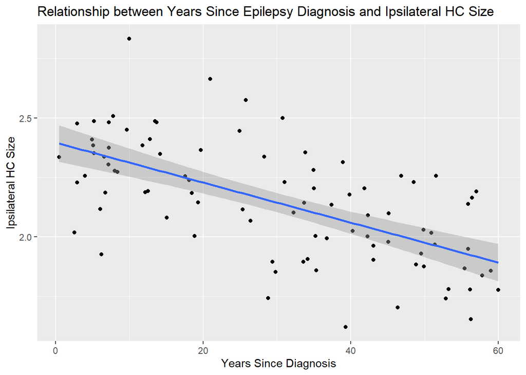

```r
epilepsy_dat %>%
  ggplot(aes(x = Years, y = IpsilateralHC)) +
  geom_point()+
  geom_smooth(method = "lm") +
  labs(title = "Relationship between Years Since Epilepsy Diagnosis and Ipsilateral HC Size",
       x = "Years Since Diagnosis",
       y = "Ipsilateral HC Size")
```